# Airbnb Pricing Analysis in Major European Cities

Hill Zhang 2024-05-05

- Project Summary
- Reproducibility
- Introduction
- Data
- Ethical considerations
- Data import
- Data cleaning
- Analysis
- Conclusions and next steps

```r
library(tidyverse)
library(ggplot2)
#install.packages("ggiraphExtra")
#library(ggiraphExtra)
library(modelr)
options(na.action = na.warn)

data_dir <- if (dir.exists('data/raw')) 'data/raw' else '.'
```

## Project Summary

- **Goal:** quantify what drives Airbnb listing prices across major European cities, and compare weekday vs weekend pricing.
- **Data:** Kaggle dataset *Airbnb Prices in European Cities* (20 CSV files, 10 cities, weekdays vs weekends).
- **Methods:** data cleaning + exploratory analysis (distribution/outliers), then linear regression and log-linear regression with basic residual checks.
- **Key takeaways (high level):**
  - **Room type** is a strong predictor. Entire homes tend to price higher than private or shared rooms.
  - **Location matters.** Listings closer to city centers and metro stations tend to price higher.
  - **Weekday vs weekend** price differences are small in this dataset.
  - **Log-transforming price** improves fit for skewed price distributions with outliers.

## Reproducibility

1. Download the dataset from Kaggle (linked below) and place the CSVs in a folder such as `data/raw/`.
2. Update the `read_csv()` paths in the Data import section if needed.
3. Knit this R Markdown file to HTML (or render to GitHub Markdown).

## Introduction

This project explores the complex dynamics of Airbnb pricing across major European cities, aiming to understand the factors influencing listing prices on this popular accommodation-sharing platform. The analysis examines how various attributes such as room type, host status, and location factors individually and collectively affect prices. The investigation is structured around four key questions. The first three questions focus on the relationship between individual factors and listing prices, exploring the influence of day types (weekdays or weekends), room types (entire home, private room, and shared rooms), and location. The final question examines how these attributes collectively impact the listing price through modeling.

The analysis provides multiple crucial findings. Room type serves as a significant predictor of pricing, with entire homes generally commanding higher prices than private or shared rooms. Proximity to city centers and metro stations also significantly influenced prices, with listings closer to these hubs demanding higher rates. Interestingly, prices did not vary significantly between weekdays and weekends, which contradicts common expectations. Additionally, the use of a log-transformed linear regression model emphasized the importance of transforming skewed data to enhance model fit and interpretability. This model was particularly effective, explaining a significant portion of the variability in prices and outperforming the standard linear model. The insights from this study offer valuable guidance several different groups: 1. travelers seeking for better pricing; 2. hosts looking to optimize their pricing strategies; 3. policymakers aiming to understand the impact of various factors on local accommodation markets.

## Data

The dataset for the project “Determinants of Airbnb Prices in European Cities” is obtained from the supplementary materials provided by Kristóf Gyódi and Łukasz Nawaro for their research article published in Tourism Management. Their article, “Determinants of Airbnb Prices in European Cities: A Spatial Econometrics Approach,” employs spatial regression models to uncover factors that influence Airbnb pricing across major European cities. This extensive dataset includes data for both weekday and weekend listings and encompasses a variety of attributes such as accommodation type, room privacy, capacity, superhost status, and cleanliness ratings. Additionally, it contains geographic details like proximity to city centers and metro stations. The data was evenly collected to facilitate a detailed spatial econometric analysis aimed at unraveling the complex pricing dynamics within the Airbnb market.

The authors have meticulously documented the dataset, ensuring each entry is enriched with attributes essential for a multi-dimensional analysis. Although the dataset provides comprehensive information on pricing and property characteristics, it lacks temporal context, which could elucidate market trends over time. Integrating data on the timing of collection could enable the analysis of seasonal or annual variations in pricing strategies and guest preferences. The complete dataset is publicly available on Kaggle under the URL https://www.kaggle.com/datasets/thedevastator/airbnb-prices-in-european-cities/data, ensuring the transparency and reproducibility of the research findings.

## Ethical considerations

Utilizing the “Determinants of Airbnb Prices in European Cities” dataset brings to light several ethical considerations. First, regarding privacy concerns, the dataset includes detailed information about Airbnb listings, such as geographical coordinates and the host’s ‘superhost’ status. It is vital to ensure that no individual host or property is identifiable from the dataset to maintain security and privacy.

Second, the analysis of Airbnb pricing and its determinants can have broader socio-economic impacts. For example, insights from this study could influence Airbnb’s pricing strategies or guide regulatory actions by local governments. If employed responsibly, this data can promote fair pricing practices and help cities manage the impact of short-term rentals on local housing markets. Conversely, if misused, this data could manipulate market prices or exacerbate housing shortages.

Lastly, the potential misuse of this dataset by third parties for purposes not originally intended, such as targeting specific demographics or neighborhoods for commercial benefits, presents ethical challenges. It is imperative to acknowledge these implications and ensure that any analysis or dissemination of findings is conducted transparently and adheres to ethical standards, aiming to positively influence the communities impacted by the data.

## Data import

The initial step in our analysis involves importing the dataset for Airbnb prices across several major European cities. The dataset is structured to provide separate files for each city that detail Airbnb pricing information for both weekdays and weekends. Here, we’ve imported data for ten cities: Amsterdam, Athens, Barcelona, Berlin, Budapest, Lisbon, London, Paris, Rome, and Vienna. For each city, we load two separate files: one for weekdays and one for weekends.

```r
amsterdam_weekdays <- read_csv(file.path(data_dir, "amsterdam_weekdays.csv"))
amsterdam_weekends <- read_csv(file.path(data_dir, "amsterdam_weekends.csv"))
athens_weekdays <- read_csv(file.path(data_dir, "athens_weekdays.csv"))
athens_weekends <- read_csv(file.path(data_dir, "athens_weekends.csv"))
barcelona_weekdays <- read_csv(file.path(data_dir, "barcelona_weekdays.csv"))
barcelona_weekends <- read_csv(file.path(data_dir, "barcelona_weekends.csv"))
berlin_weekdays <- read_csv(file.path(data_dir, "berlin_weekdays.csv"))
berlin_weekends <- read_csv(file.path(data_dir, "berlin_weekends.csv"))
budapest_weekdays <- read_csv(file.path(data_dir, "budapest_weekdays.csv"))
budapest_weekends <- read_csv(file.path(data_dir, "budapest_weekends.csv"))
lisbon_weekdays <- read_csv(file.path(data_dir, "lisbon_weekdays.csv"))
lisbon_weekends <- read_csv(file.path(data_dir, "lisbon_weekends.csv"))
london_weekdays <- read_csv(file.path(data_dir, "london_weekdays.csv"))
london_weekends <- read_csv(file.path(data_dir, "london_weekends.csv"))
paris_weekdays <- read_csv(file.path(data_dir, "paris_weekdays.csv"))
paris_weekends <- read_csv(file.path(data_dir, "paris_weekends.csv"))
rome_weekdays <- read_csv(file.path(data_dir, "rome_weekdays.csv"))
rome_weekends <- read_csv(file.path(data_dir, "rome_weekends.csv"))
vienna_weekdays <- read_csv(file.path(data_dir, "vienna_weekdays.csv"))
vienna_weekends <- read_csv(file.path(data_dir, "vienna_weekends.csv"))
```

## Data cleaning

### Data Tidying and Cleaning

First, we will modify each city’s dataset by adding a new column day_type indicating whether the data is from a weekday or weekend. We then join the ‘weekdays’ and ‘weekend’ datasets of individual datasets into one dataset for a particular city, using full_join function. We also add a new column city to each joined dataset, since we will be combining all these cities datasets and thus would need to differentiate the data of cities in some way for analysis and insights. This approach maintains clarity and allows for detailed comparative analyses across days and cities.

```r
amsterdam <- full_join(amsterdam_weekdays %>% mutate(day_type = "Weekday"),
                       amsterdam_weekends %>% mutate(day_type = "Weekend")) %>% mutate(city = "Amsterdam")
athens <- full_join(athens_weekdays %>% mutate(day_type = "Weekday"),
                    athens_weekends %>% mutate(day_type = "Weekend")) %>% mutate(city = "Athens")
barcelona <- full_join(barcelona_weekdays %>% mutate(day_type = "Weekday"),
                       barcelona_weekends %>% mutate(day_type = "Weekend")) %>% mutate(city = "Barcelona")
berlin <- full_join(berlin_weekdays %>% mutate(day_type = "Weekday"),
                    berlin_weekends %>% mutate(day_type = "Weekend")) %>% mutate(city = "Berlin")
budapest <- full_join(budapest_weekdays %>% mutate(day_type = "Weekday"),
                      budapest_weekends %>% mutate(day_type = "Weekend")) %>% mutate(city = "Budapest")
lisbon <- full_join(lisbon_weekdays %>% mutate(day_type = "Weekday"),
                    lisbon_weekends %>% mutate(day_type = "Weekend")) %>% mutate(city = "Lisbon")
london <- full_join(london_weekdays %>% mutate(day_type = "Weekday"),
                    london_weekends %>% mutate(day_type = "Weekend")) %>% mutate(city = "London")
paris <- full_join(paris_weekdays %>% mutate(day_type = "Weekday"),
                   paris_weekends %>% mutate(day_type = "Weekend")) %>% mutate(city = "Paris")
rome <- full_join(rome_weekdays %>% mutate(day_type = "Weekday"),
                  rome_weekends %>% mutate(day_type = "Weekend")) %>% mutate(city = "Rome")
vienna <- full_join(vienna_weekdays %>% mutate(day_type = "Weekday"),
                    vienna_weekends %>% mutate(day_type = "Weekend")) %>% mutate(city = "Vienna")
```

The next step involves combining these city-specific datasets into a single dataset. Since our prior checks confirmed that all individual city datasets share the same columns, we utilize bind_rows function to combine them into a single comprehensive dataset for easier analysis across multiple dimensions.

```r
airbnb <- bind_rows(amsterdam, athens, barcelona, berlin, budapest, lisbon, london, paris, rome, vienna) %>% select(-c(...1, room_shared, room_private)) %>% select(city, day_type, everything())
airbnb
```

```
## # A tibble: 51,707 × 19
##    city      day_type realSum room_type  person_capacity host_is_superhost multi
##    <chr>     <chr>      <dbl> <chr>                <dbl> <lgl>             <dbl>
##  1 Amsterdam Weekday     194. Private r…               2 FALSE                 1
##  2 Amsterdam Weekday     344. Private r…               4 FALSE                 0
##  3 Amsterdam Weekday     264. Private r…               2 FALSE                 0
##  4 Amsterdam Weekday     434. Private r…               4 FALSE                 0
##  5 Amsterdam Weekday     486. Private r…               2 TRUE                  0
##  6 Amsterdam Weekday     553. Private r…               3 FALSE                 0
##  7 Amsterdam Weekday     215. Private r…               2 FALSE                 0
##  8 Amsterdam Weekday    2771. Entire ho…               4 TRUE                  0
##  9 Amsterdam Weekday    1002. Entire ho…               4 FALSE                 0
## 10 Amsterdam Weekday     277. Private r…               2 FALSE                 1
## # ℹ 51,697 more rows
## # ℹ 12 more variables: biz <dbl>, cleanliness_rating <dbl>,
## #   guest_satisfaction_overall <dbl>, bedrooms <dbl>, dist <dbl>,
## #   metro_dist <dbl>, attr_index <dbl>, attr_index_norm <dbl>,
## #   rest_index <dbl>, rest_index_norm <dbl>, lng <dbl>, lat <dbl>
```

This final combined dataset named airbnb now serves as the basis for all subsequent analyses. It contains unified data from all selected European cities, enabling us to perform comparative and statistical analyses more effectively.

### Missing Datas

We will check for missing values across the entire consolidated airbnb dataset. This was accomplished using the **is.na** function combined with the **any** function, which helps in identifying any missing values across all columns and rows.

```r
any(is.na(airbnb))
```

```
## [1] FALSE
```

The result of this operation confirmed that there are no missing (NA) values within the dataset. This finding indicates that our dataset is well-prepared and does not require further steps commonly associated with handling missing data. To prepare for the next phase of our analysis, we can aim to explore and model the data without concerns regarding data completeness or the need to address missing information.

## Analysis

### Adjusting Outliers in listing prices

Outliers are extreme values that fall significantly outside the typical range of data. In the context of Airbnb prices, these are unusually high or low prices that do not represent typical listings.

To better understand the distribution of listing prices and the extent of outliers, a density plot is drawed:

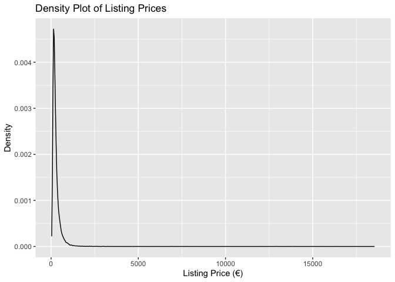

```r
ggplot(data = airbnb) + geom_density(aes(x = realSum)) +
  labs(title = "Density Plot of Listing Prices",
       x = "Listing Price (€)",
       y = "Density")
```

The lower-priced listings are concentrated near the origin with a sharp peak. The plot also displays a long tail extending toward higher prices. This long tail indicates the presence of outliers — listings that are priced significantly higher than the typical market rate. These could be luxury accommodations or properties in extremely high-demand locations.

To accurately identify outliers in listing prices, i.e. the realSum column, we utilize the interquartile range (IQR) method:

```r
iqr <- IQR(airbnb$realSum)
lower_bound <- quantile(airbnb$realSum, 0.25) - 1.5 * iqr
upper_bound <- quantile(airbnb$realSum, 0.75) + 1.5 * iqr
outliers <- airbnb$realSum < lower_bound | airbnb$realSum > upper_bound
percentage_outliers <- sum(outliers) / nrow(airbnb) * 100

percentage_outliers
```

```
## [1] 7.082213
```

Using IQR() function and quantile() function, we identified outliers that are greater than upper_bound and less than lower_bound. We create a logical vector where each element is TRUE if the corresponding price in airbnb$realSum is an outliers. To understand the extent of the outlier issue, we calculate the percentage of listing prices that are considered outliers. This is done by summing the TRUE values in the outliers vector and dividing by the total number of listings in the dataset. The percentage of outliers is 7.08% of the total pricing data.

The skewness caused by high-price outliers may complicate average price calculations and statistical modeling. Therefore, we applied a logarithmic transformation of the price data. This transformation compresses the range of higher prices more effectively than lower ones, thus minimizing the influence of extreme values and enhancing the clarity of visualization. It also renders the distribution more suitable for statistical methods that require a normal distribution.

```r
airbnb_norm <- airbnb %>% mutate(realSum = log10(realSum))
```

This final combined dataset named airbnb_norm now serves as the basis for all subsequent analyses.

### Analysis 1: How is the listing price distributed across major European cities? How does it vary between weekdays and weekends?

To comprehensively explore the distribution of listings across cities and differentiate between weekdays and weekends, a bar chart was employed:

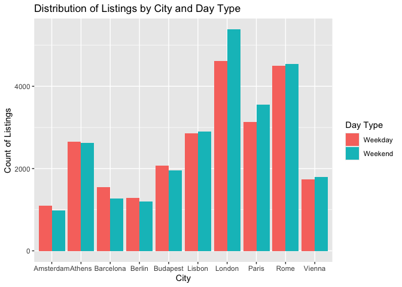

```r
ggplot(data = airbnb_norm) + geom_bar(aes(fill = day_type, x = city), position = "dodge") +
  labs(
    title = "Distribution of Listings by City and Day Type",
    x = "City",
    y = "Count of Listings",
    fill = "Day Type")
```

Boxplots were used to visually represent the price distribution across cities and by day type. We use boxplots because it foucs on the median and quartiles listing prices, which are less sentitive to outliers than means. It helps in observing the spread and central values of prices without the skewing effect of extreme outliers.

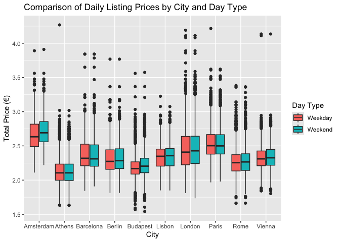

```r
ggplot(data = airbnb_norm) + geom_boxplot(aes(x = city, y = realSum, fill = day_type))  +
  labs(x = "City",
       y = "Total Price (€)",
       title = "Comparison of Daily Listing Prices by City and Day Type",
       fill = "Day Type")
```

There is no significant difference in median listing prices between weekdays and weekends, which contradicts the common expectation of weekend premium. This anomaly suggests that other factors such as location desirability, local events, or seasonal demand might play more significant roles in pricing than merely the day of the week. The near-uniform pricing between weekdays and weekends across all cities highlights a unique aspect of the European Airbnb market, potentially driven by consistent tourist demand or effective price regulation strategies by hosts to maintain competitive yet stable pricing.

### Analysis 2: How do room types influence Airbnb pricing across major European cities?

We start by evaluating the distribution of room types — entire homes/apartments, private rooms, and shared rooms — across cities. In the following code, the original data is grouped by city and room type, and the percentage of each room type is calculated within its respective city.

This data is then plotted as a composition chart where each bar represents a city and is filled according to the proportion of room types. The **position = “fill”** ensures that each bar is normalized to fill the y-axis, facilitating direct comparison across cities. The use of **geom_text()** add text annotations to display exact percentages within the bars.

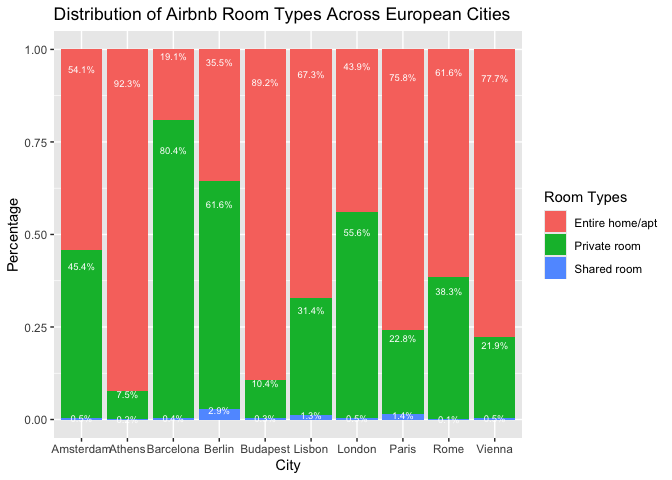

```r
airbnb_counts <- airbnb_norm %>%
  count(city, room_type) %>%
  group_by(city) %>%
  mutate(percentage = n / sum(n)) %>%
  ungroup()

ggplot(airbnb_counts, aes(x = city, y = percentage, fill = room_type)) +
  geom_bar(stat = "identity", position = "fill") +
  geom_text(aes(label = scales::percent(percentage, accuracy = 0.1)),
            position = position_fill(vjust = 0.9), # Adjust vertical position inside the bars
            color = "white", size = 2.5) +  # You can adjust color and size of text for better visibility
  labs(x = "City", y = "Percentage", fill = "Room Types",
       title = "Distribution of Airbnb Room Types Across European Cities")
```

From the composition chart, we could obsevere significant differences in the proportion of the room type accross cities. The vast majority (above 70%) of listings are entire homes in Athens, Budapest, Paris and Vienna. This indicates a market preference for more spacious and private accommodations which cater to tourists and families. This preference aligns with these cities’ reputations as major tourist destinations where visitors often seek comfort and privacy.

On the other hand, private rooms constitute more than 60% of listings in Barcelona and Berlin. It likely reflects local regulatory influences that restrict certain types of short-term rentals. For instance, stringent regulations in Barcelona aim to protect local housing markets by limiting private rentals.

Next, we explore how room types affect listing prices within these cities. Again, boxplots are used in visualization to mitigate the effect of outliers by focusing on median listing prices.

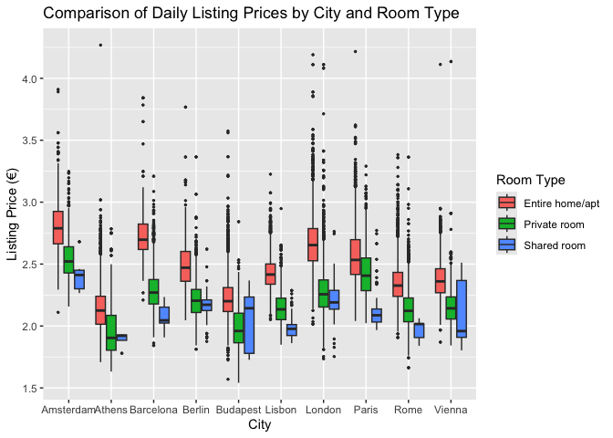

```r
ggplot(data = airbnb_norm, aes(x = city, y = realSum, fill = room_type)) +
  geom_boxplot(outlier.size = 0.5) +
  labs(x = "City",
       y = "Listing Price (€)",
       title = "Comparison of Daily Listing Prices by City and Room Type",
       fill = "Room Type")
```

### Analysis 3: How do different location factors affect Airbnb pricing across major European cities?

We focus on four location-specific factors: 1. dist: distance from city center in kilometers; 2. metro_dist: distance from nearest metro station in kilometers; 3. attr_index_norm: normalized attraction index of the listing location from a scale 0-100; 4. rest_index_norm: normalized restaurant index of the listing location, from a scale 0-100.

We employed linear models to assess the correlation between distance from city centers and metro stations on listing prices. The models were visualized using trend lines(geom_smooth) for each city, represented by different colors. A subset of the data (sampled_data) is created by randomly selecting 20 listings from each city to ensure that the plot remains clear and not overly cluttered. This sampling is performed within a grouped structure by city. On the plots, each point represents a sampled listing, aligning with the corresponding city’s color and grouped by city to ensure consistent trend analysis.

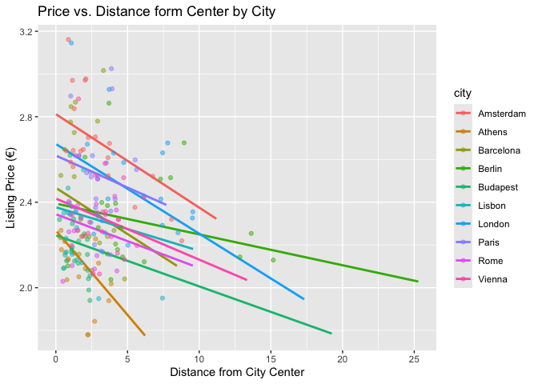

```r
sampled_data <- airbnb_norm %>% group_by(city) %>% sample_n(size = 20)

dist_realSum <- ggplot(data = airbnb_norm, aes(x = dist, y = realSum, color = city)) +
  geom_smooth(method = "lm", se = FALSE, aes(group = city)) +
  geom_point(data = sampled_data, aes(group = city), alpha = 0.5) +
  labs(y = "Listing Price (€)", x = "Distance from City Center", title = "Price vs. Distance form Center by City")
dist_realSum
```

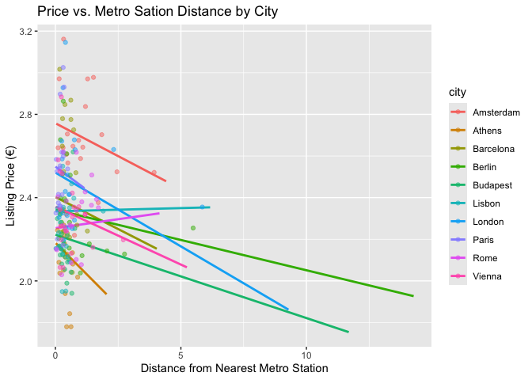

```r
metrodist_realSum <- ggplot(data = airbnb_norm, aes(x = metro_dist, y = realSum, color = city)) +
  geom_smooth(method = "lm", se = FALSE, aes(group = city)) +
  geom_point(data = sampled_data, aes(group = city), alpha = 0.5) +
  labs(y = "Listing Price (€)", x = "Distance from Nearest Metro Station", title = "Price vs. Metro Sation Distance by City")
metrodist_realSum
```

Further, we extended our exploration to the effects of the attractions and restaurants indexes, using a similar modeling approach.

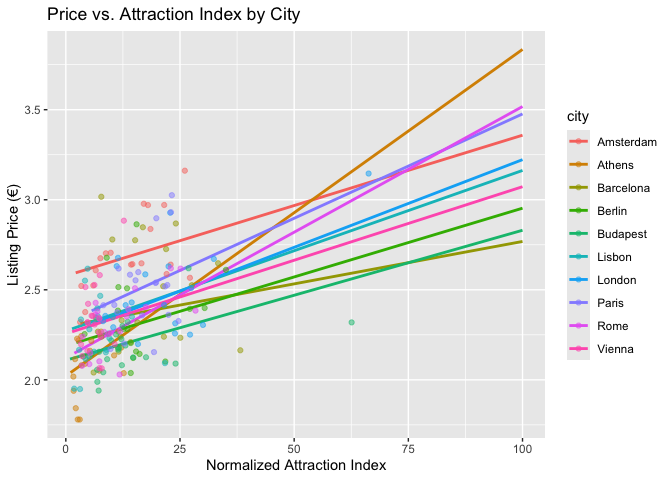

```r
attr_realSum <- ggplot(data = airbnb_norm, aes(x = attr_index_norm, y = realSum, color = city)) +
  geom_smooth(method = "lm", se = FALSE, aes(group = city)) +
  geom_point(data = sampled_data, aes(group = city), alpha = 0.5) +
  labs(y = "Listing Price (€)", x = "Normalized Attraction Index", title = "Price vs. Attraction Index by City")
attr_realSum
```

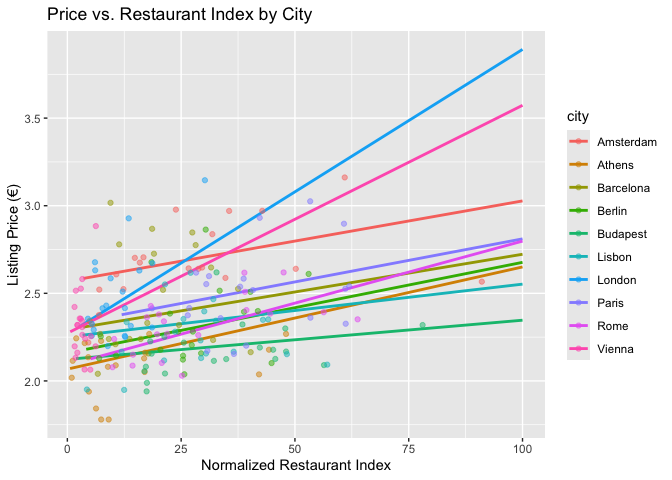

```r
rest_realSum <- ggplot(data = airbnb_norm, aes(x = rest_index_norm, y = realSum, color = city)) +
  geom_smooth(method = "lm", se = FALSE, aes(group = city)) +
  geom_point(data = sampled_data, aes(group = city), alpha = 0.5) +
  labs(y = "Listing Price (€)", x = "Normalized Restaurant Index", title = "Price vs. Restaurant Index by City")
rest_realSum
```

### Model 1: Multivariable linear model for Airbnb listing prices (realSum)

**Methodology**

The analysis utilized a dataset airbnb filtered to include only listings located in the city of London. The linear regression model was employed to predict the listing prices (realSum) based on various explanatory variables including room type, person capacity, number of bedrooms, distance from city center (dist), distance from the nearest metro station (metro_dist), normalized attraction index (attr_index_norm), normalized restaurant index (rest_index_norm), overall guest satisfaction, cleanliness rating, and whether the host is a superhost (host_is_superhost).

```r
london_price <- airbnb %>% filter(city == "London")

mod_london <- lm(realSum ~ room_type + person_capacity + bedrooms +
                           dist + metro_dist + attr_index_norm + rest_index_norm +
                           guest_satisfaction_overall + cleanliness_rating + host_is_superhost,
                 data = london_price)
summary(mod_london)
```

```
##
## Call:
## lm(formula = realSum ~ room_type + person_capacity + bedrooms +
##     dist + metro_dist + attr_index_norm + rest_index_norm + guest_satisfaction_overall +
##     cleanliness_rating + host_is_superhost, data = london_price)
##
## Residuals:
##     Min      1Q  Median      3Q     Max
##  -993.6   -97.8   -28.5    41.0 14177.4
##
## Coefficients:
##                              Estimate Std. Error t value Pr(>|t|)
## (Intercept)                -165.85478   46.97437  -3.531 0.000416 ***
## room_typePrivate room      -201.91650   10.28852 -19.625  < 2e-16 ***
## room_typeShared room       -242.62259   59.08165  -4.107 4.05e-05 ***
## person_capacity              33.85611    4.86443   6.960 3.62e-12 ***
## bedrooms                    173.31231    8.96684  19.328  < 2e-16 ***
## dist                          9.18234    3.31992   2.766 0.005688 **
## metro_dist                  -21.48787    4.74851  -4.525 6.10e-06 ***
## attr_index_norm               9.32645    0.92143  10.122  < 2e-16 ***
## rest_index_norm               0.01779    1.40132   0.013 0.989870
## guest_satisfaction_overall    1.21899    0.55558   2.194 0.028251 *
## cleanliness_rating            1.85978    5.44959   0.341 0.732908
## host_is_superhostTRUE        20.74060   11.76652   1.763 0.077985 .
## ---
## Signif. codes:  0 '***' 0.001 '**' 0.01 '*' 0.05 '.' 0.1 ' ' 1
##
## Residual standard error: 413.7 on 9981 degrees of freedom
## Multiple R-squared:  0.2306, Adjusted R-squared:  0.2298
## F-statistic:   272 on 11 and 9981 DF,  p-value: < 2.2e-16
```

**Analysis of the summary data and insights**  
The summary data of this model shows that it explains approximately 23% of the variance in listing prices (Adjusted R-squared = 0.2298). While this is significant, it suggests that many other unaccounted factors could also impact pricing.

**Predictive accuracy**

To assess the model’s predictive performance, we first add predictions and residuals to the original data set, using the model london_mod we created along with add_predictions and add_residuals function.

The predicted prices were plotted against actual prices:

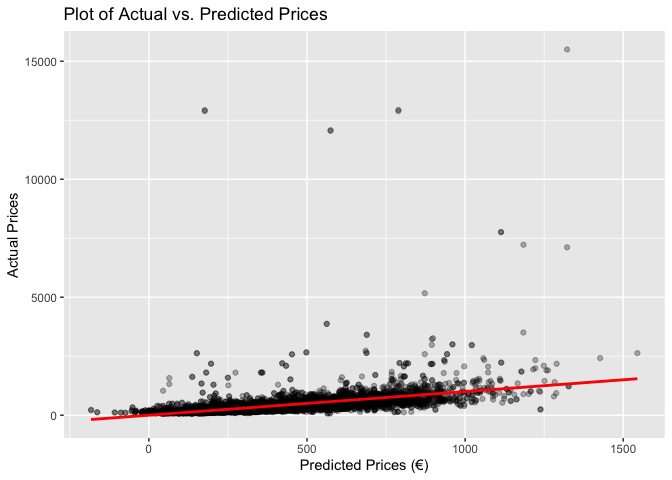

```r
london_price_pred_resid <- london_price %>% add_predictions(mod_london) %>% add_residuals(mod_london)

ggplot(data = london_price_pred_resid, aes(x = pred, y = realSum)) +
  geom_point(alpha = 0.3) +
  geom_smooth(method = "lm", se = FALSE, color = "red") +
  labs(x = "Predicted Prices (€)", y = "Actual Prices", title = "Plot of Actual vs. Predicted Prices")
```

The plot of actual versus predicted prices demonstrates that the linear model predicts lower-priced listings relatively well, as the actual data points are clustered around the predicted line at lower price levels. However, as the price increases, the data points begin to spread from the line, suggesting that the model’s accuracy decreases for luxury listings. The presence of several high-priced listings that are far from the predicted values indicates that the model does not fully capture the factors that lead to higher prices.

The residuals were plotted against Predicted prices:

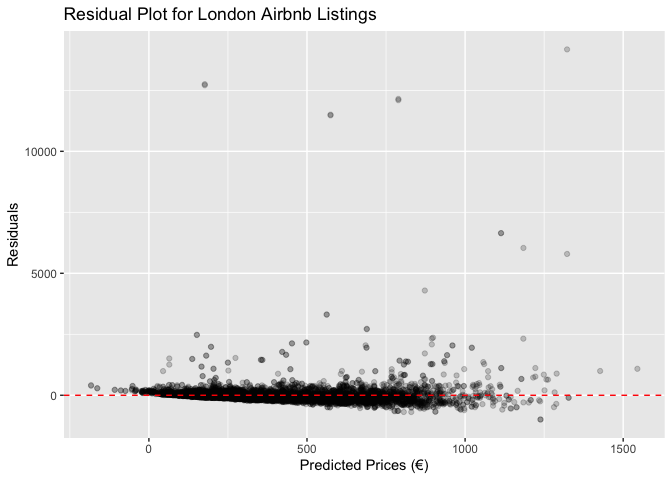

```r
ggplot(london_price_pred_resid, aes(x = pred, y = resid)) +
  geom_point(alpha = 0.2) +
  geom_hline(yintercept = 0, linetype = "dashed", color = "red") +
  labs(x = "Predicted Prices (€)", y = "Residuals", title = "Residual Plot for London Airbnb Listings")
```

The majority of residuals are ditributed around the zero line, suggesting that the model’s predictions are unbiased on average. However, there is a slightly downward trend of residuals, suggesting this model may overestimates prices for lower-cost listings. Additionally, there are several outliers where the model significantly underestimates or overestimates prices. These outliers likely represent unique properties that are not adequately captured by the model’s current variables.

### Model 2: Log-transformed model for London Airbnb listing prices (realSum)

**Methodology**

Considering the presence of exceptionally high listing prices in the original data, we would like to explore the log-transformed model to see if this transformation could improve the model fit. We used the airbnb_norm dataset, where a log transformation has been applied to the realSum column, representing the listing prices.

```r
log_london_price <- airbnb_norm %>% filter(city == "London")

mod_log <- lm(realSum ~ room_type + person_capacity + bedrooms +
                           dist + metro_dist + attr_index_norm + rest_index_norm +
                           guest_satisfaction_overall + cleanliness_rating + host_is_superhost,
                 data = log_london_price)
summary(mod_log)
```

```
##
## Call:
## lm(formula = realSum ~ room_type + person_capacity + bedrooms +
##     dist + metro_dist + attr_index_norm + rest_index_norm + guest_satisfaction_overall +
##     cleanliness_rating + host_is_superhost, data = log_london_price)
##
## Residuals:
##      Min       1Q   Median       3Q      Max
## -0.50637 -0.10363 -0.01969  0.07729  1.88386
##
## Coefficients:
##                              Estimate Std. Error t value Pr(>|t|)
## (Intercept)                 2.1678755  0.0181893 119.184  < 2e-16 ***
## room_typePrivate room      -0.2797985  0.0039839 -70.232  < 2e-16 ***
## room_typeShared room       -0.3379881  0.0228774 -14.774  < 2e-16 ***
## person_capacity             0.0434549  0.0018836  23.070  < 2e-16 ***
## bedrooms                    0.0851468  0.0034721  24.523  < 2e-16 ***
## dist                       -0.0051209  0.0012855  -3.983 6.84e-05 ***
## metro_dist                 -0.0237809  0.0018387 -12.934  < 2e-16 ***
## attr_index_norm             0.0040039  0.0003568  11.222  < 2e-16 ***
## rest_index_norm             0.0022720  0.0005426   4.187 2.85e-05 ***
## guest_satisfaction_overall  0.0003245  0.0002151   1.509    0.131
## cleanliness_rating          0.0141215  0.0021102   6.692 2.32e-11 ***
## host_is_superhostTRUE       0.0197654  0.0045562   4.338 1.45e-05 ***
## ---
## Signif. codes:  0 '***' 0.001 '**' 0.01 '*' 0.05 '.' 0.1 ' ' 1
##
## Residual standard error: 0.1602 on 9981 degrees of freedom
## Multiple R-squared:  0.6757, Adjusted R-squared:  0.6754
## F-statistic:  1891 on 11 and 9981 DF,  p-value: < 2.2e-16
```

**Analysis of Predictive Accuracy**

The adjusted R-squared of 0.6754. It suggest that approximately 67.54% of the variability in Airbnb listing prices in London is explained by the model. Comparing this to the previous model using non-transformed data with a R-squared of 0.2298, the log-transformed model shows improved fit statistics.

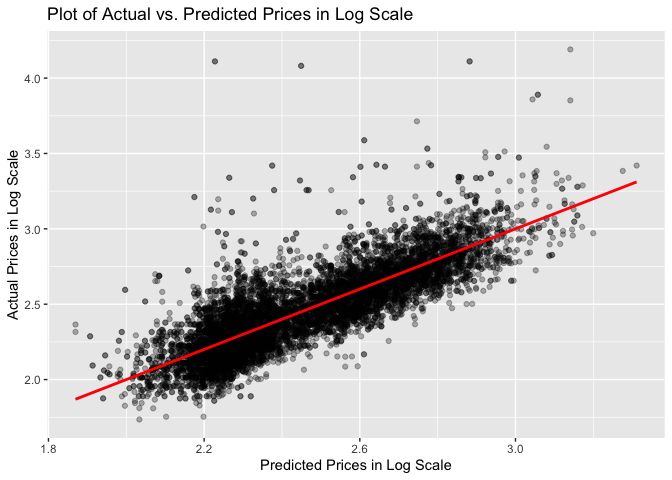

```r
log_london_price_pred_resid <- log_london_price %>% add_predictions(mod_log) %>% add_residuals(mod_log)

ggplot(data = log_london_price_pred_resid, aes(x = pred, y = realSum)) +
  geom_point(alpha = 0.3) +
  geom_smooth(method = "lm", se = FALSE, color = "red") +
  labs(x = "Predicted Prices in Log Scale", y = "Actual Prices in Log Scale", title = "Plot of Actual vs. Predicted Prices in Log Scale")
```

The plot of actual versus predicted prices on a log scale demonstrates a strong linear relationship, with most data points closely aligned with the red trend line. This indicates effective price prediction for most listings using the log-transformed model.

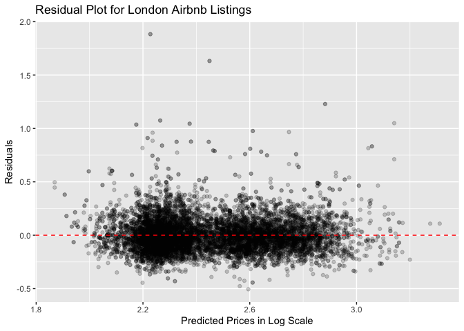

```r
ggplot(log_london_price_pred_resid, aes(x = pred, y = resid)) +
  geom_point(alpha = 0.2) +
  geom_hline(yintercept = 0, linetype = "dashed", color = "red") +
  labs(x = "Predicted Prices in Log Scale", y = "Residuals", title = "Residual Plot for London Airbnb Listings")
```

Residuals are centered around zero without a discernible pattern, which supports the validity of the regression results. However, some outliers at both ends implies limitations in capturing extreme values with the current predictors.

## Conclusions and next steps

This project conducted an in-depth analysis of the factors influencing Airbnb listing prices across major European cities, drawing from a dataset that included a variety of property, location, and host-related attributes. The analysis highlighted clear correlations between Airbnb prices and key variables such as room type and proximity to city centers and metro stations. In conclusion, the log-transformed linear regression model is a better prediction over the linear model without transformation. It is effective in dealing with the skewed distributions with the presence of outliers that are often found in pricing data.

Despite the valuable insights, the study has several limitations. The analysis was confined to data from European cities, leaving it uncertain whether the observed patterns would be applicable in other global regions under different economic conditions and regulatory frameworks. Additionally, the dataset lacked detailed temporal information that could influence pricing, such as seasonal fluctuations or special events, potentially introducing variability to our price predictions. There are also limitations in the modeling approach. Currently, each variable is weighted equally, whereas in reality, some variables may have a more significant impact at different price ranges.

For future research, expanding the dataset to include information from other continents could validate whether the observed relationships are consistent globally. When creating the model, different weights could be put onto the variables to enhance the accuracy of the predictions. Exploring a correlation matrix between these predictors and listing prices could assist in assigning differentiated weights to each variable, better reflecting the real-world scenario of pricing.